# Machine Learning

## Apartment Price Investigation - Phase II

### Radhika Zawar S3734939

#### This report is organised as follow:

- Section 2. Overview - methodology outline
- Section 3. Data Preparation - brief dataset summary and method evaluation styrategy
- Section 4. Feature selection and Hyperparameter Tuning - Describe most important features as well as the parameter tuning process for each regression algorithm
- Section 5. Performance Comparison - presents model performance comparison results
- Section 6. Limitations - discusses a limitations of our approach and possible solutions
- Section 7. Summary - provides a brief summary of our work in this project

Compiled from a Jupyter Notebook, this report contains both narratives and the Python code used throughout the project.

### Overview

#### Methodology:

Following regression algorithms are used to predict the target feature.

- Linear Regressor
- K-Nearest Neighbors Regressor
- Decision trees Regressor

The modeling strategy begins by transforming the dataset which was cleaned in Phase I. This transformation includes encoding categorical descriptive features as numerical and then scaling of the descriptive features. Then the data was split on 70%-30% split. At the end of splitting, training set has 4123 and test set has 1768 rows.

Before fitting a perticular model, we have selected importatnt feature using various feature selection methods. In this step, we have used F-score, Mutual Information, Random Forest Importance. Further we also compared the performanve of the different feature selection methods.

Once the best model is identified for K-Nearest Neighbors Regressor and Decision trees Regressors using a hyperparameter search on the training data, We present visual plot to demonstrate performance of each algorithm. Further, we conduct a 5-fold cross-validation on the test data and perform a paired t-test to see if any performance difference is statistically significant. In addition, we compare the Regressors with respect to their scores on the test data.

### Data Prepation

#### Loading dataset:

The dataset which was cleaned and processed in phase I of this project is loaded in CSV format for further investigation.

```python
import pandas as pd
from pandas.tools.plotting import scatter_matrix
import numpy as np
import matplotlib.pyplot as plt
import seaborn as sns
from sklearn import preprocessing

import io
import requests
import os, ssl


apartment_df = pd.read_csv('apartment_final.csv', decimal = '.')

print apartment_df.shape
```

```
(5891, 20)
```

```python
apartment_df.head(5)
```

|  | Unnamed: 0 | SalePrice | YearBuilt | YrSold | Size.sqf. | Floor | HallwayType | HeatingType | AptManageType | N_Parkinglot.Basement. | TimeToBusStop | TimeToSubway | N_manager | N_elevators | SubwayStation | N_FacilitiesNearBy.Dpartmentstore. | N_FacilitiesNearBy.Park. | N_FacilitiesInApt | N_FacilitiesNearBy.Total. | N_SchoolNearBy.Total. |
| --- | --- | --- | --- | --- | --- | --- | --- | --- | --- | --- | --- | --- | --- | --- | --- | --- | --- | --- | --- | --- |
| 0 | 1 | 141592 | 2006 | 2007 | 814 | 3 | terraced | individual_heating | management_in_trust | 184 | 5min~10min | 10min~15min | 3 | 0 | Kyungbuk_uni_hospital | 1 | 0 | 5 | 6 | 9 |
| 1 | 2 | 51327 | 1985 | 2007 | 587 | 8 | corridor | individual_heating | self_management | 76 | 0~5min | 5min~10min | 2 | 2 | Daegu | 2 | 1 | 3 | 12 | 4 |
| 2 | 3 | 48672 | 1985 | 2007 | 587 | 6 | corridor | individual_heating | self_management | 76 | 0~5min | 5min~10min | 2 | 2 | Daegu | 2 | 1 | 3 | 12 | 4 |
| 3 | 4 | 380530 | 2006 | 2007 | 2056 | 8 | terraced | individual_heating | management_in_trust | 536 | 0~5min | 0-5min | 5 | 11 | Sin-nam | 0 | 0 | 5 | 3 | 7 |
| 4 | 5 | 221238 | 1993 | 2007 | 1761 | 3 | mixed | individual_heating | management_in_trust | 536 | 0~5min | 15min~20min | 8 | 20 | Myung-duk | 0 | 0 | 4 | 14 | 17 |

```python
apartment_df.dtypes
```

```
Unnamed: 0                             int64
SalePrice                              int64
YearBuilt                              int64
YrSold                                 int64
Size.sqf.                              int64
Floor                                  int64
HallwayType                           object
HeatingType                           object
AptManageType                         object
N_Parkinglot.Basement.                 int64
TimeToBusStop                         object
TimeToSubway                          object
N_manager                              int64
N_elevators                            int64
SubwayStation                         object
N_FacilitiesNearBy.Dpartmentstore.     int64
N_FacilitiesNearBy.Park.               int64
N_FacilitiesInApt                      int64
N_FacilitiesNearBy.Total.              int64
N_SchoolNearBy.Total.                  int64
dtype: object
```

In the output chunk, 5 heads of the data as well as the datatype of each columns are presented.

#### Checking for Missing Values

Making sure that we don't have any missing value in this dataset.

```python
apartment_df.isna().sum()
```

```
Unnamed: 0                            0
SalePrice                             0
YearBuilt                             0
YrSold                                0
Size.sqf.                             0
Floor                                 0
HallwayType                           0
HeatingType                           0
AptManageType                         0
N_Parkinglot.Basement.                0
TimeToBusStop                         0
TimeToSubway                          0
N_manager                             0
N_elevators                           0
SubwayStation                         0
N_FacilitiesNearBy.Dpartmentstore.    0
N_FacilitiesNearBy.Park.              0
N_FacilitiesInApt                     0
N_FacilitiesNearBy.Total.             0
N_SchoolNearBy.Total.                 0
dtype: int64
```

The data has no missing value.

#### Summary statistics

The summary statistics for the full data are shown below:

```python
apartment_df.describe(include = 'all')
```

|  | Unnamed: 0 | SalePrice | YearBuilt | YrSold | Size.sqf. | Floor | HallwayType | HeatingType | AptManageType | N_Parkinglot.Basement. | TimeToBusStop | TimeToSubway | N_manager | N_elevators | SubwayStation | N_FacilitiesNearBy.Dpartmentstore. | N_FacilitiesNearBy.Park. | N_FacilitiesInApt | N_FacilitiesNearBy.Total. | N_SchoolNearBy.Total. |
| --- | --- | --- | --- | --- | --- | --- | --- | --- | --- | --- | --- | --- | --- | --- | --- | --- | --- | --- | --- | --- |
| count | 5891.000000 | 5891.000000 | 5891.000000 | 5891.000000 | 5891.000000 | 5891.000000 | 5891 | 5891 | 5891 | 5891.000000 | 5891 | 5891 | 5891.000000 | 5891.000000 | 5891 | 5891.000000 | 5891.000000 | 5891.000000 | 5891.000000 | 5891.000000 |
| unique | NaN | NaN | NaN | NaN | NaN | NaN | 3 | 2 | 2 | NaN | 3 | 5 | NaN | NaN | 8 | NaN | NaN | NaN | NaN | NaN |
| top | NaN | NaN | NaN | NaN | NaN | NaN | terraced | individual_heating | management_in_trust | NaN | 0~5min | 0-5min | NaN | NaN | Kyungbuk_uni_hospital | NaN | NaN | NaN | NaN | NaN |
| freq | NaN | NaN | NaN | NaN | NaN | NaN | 3564 | 5591 | 5542 | NaN | 4509 | 2759 | NaN | NaN | 1644 | NaN | NaN | NaN | NaN | NaN |
| mean | 2946.000000 | 221218.112545 | 2002.967408 | 2012.691563 | 955.569173 | 12.026311 | NaN | NaN | NaN | 570.761670 | NaN | NaN | 6.310304 | 11.145985 | NaN | 0.896282 | 0.654218 | 5.809540 | 9.870820 | 10.864200 |
| std | 1700.729549 | 106384.186446 | 8.811782 | 2.905488 | 382.464050 | 7.548743 | NaN | NaN | NaN | 408.621075 | NaN | NaN | 3.174088 | 7.806232 | NaN | 0.810964 | 0.658320 | 2.330804 | 3.450319 | 4.438513 |
| min | 1.000000 | 32743.000000 | 1978.000000 | 2007.000000 | 135.000000 | 1.000000 | NaN | NaN | NaN | 0.000000 | NaN | NaN | 1.000000 | 0.000000 | NaN | 0.000000 | 0.000000 | 1.000000 | 0.000000 | 0.000000 |
| 25% | 1473.500000 | 144247.000000 | 1993.000000 | 2010.000000 | 644.000000 | 6.000000 | NaN | NaN | NaN | 184.000000 | NaN | NaN | 5.000000 | 5.000000 | NaN | 0.000000 | 0.000000 | 4.000000 | 8.000000 | 7.000000 |
| 50% | 2946.000000 | 207964.000000 | 2006.000000 | 2013.000000 | 910.000000 | 11.000000 | NaN | NaN | NaN | 536.000000 | NaN | NaN | 6.000000 | 11.000000 | NaN | 1.000000 | 1.000000 | 5.000000 | 9.000000 | 10.000000 |
| 75% | 4418.500000 | 291150.000000 | 2008.000000 | 2015.000000 | 1149.000000 | 17.000000 | NaN | NaN | NaN | 798.000000 | NaN | NaN | 8.000000 | 16.000000 | NaN | 2.000000 | 1.000000 | 7.000000 | 13.000000 | 15.000000 |
| max | 5891.000000 | 585840.000000 | 2015.000000 | 2017.000000 | 2337.000000 | 43.000000 | NaN | NaN | NaN | 1321.000000 | NaN | NaN | 14.000000 | 27.000000 | NaN | 2.000000 | 2.000000 | 10.000000 | 16.000000 | 17.000000 |

#### Encoding Categorical Features

Prior to modeling, it is essential to encode all categorical features into a set of numerical features.

Encoding the descriptive Feature - We remove the first column which is the index of dataset from the full dataset and then we sepearte Target feature from the dataset and call it "Target". The rest of the features are the descriptive features which we call "Data".

```python
Apartment = apartment_df.drop(columns = 'Unnamed: 0')
Apartment.columns

Target  = Apartment['SalePrice']
print Target.head(5)

Data = Apartment.drop(columns = 'SalePrice')
Data.head(5)
```

```
0    141592
1     51327
2     48672
3    380530
4    221238
Name: SalePrice, dtype: int64
```

|  | YearBuilt | YrSold | Size.sqf. | Floor | HallwayType | HeatingType | AptManageType | N_Parkinglot.Basement. | TimeToBusStop | TimeToSubway | N_manager | N_elevators | SubwayStation | N_FacilitiesNearBy.Dpartmentstore. | N_FacilitiesNearBy.Park. | N_FacilitiesInApt | N_FacilitiesNearBy.Total. | N_SchoolNearBy.Total. |
| --- | --- | --- | --- | --- | --- | --- | --- | --- | --- | --- | --- | --- | --- | --- | --- | --- | --- | --- |
| 0 | 2006 | 2007 | 814 | 3 | terraced | individual_heating | management_in_trust | 184 | 5min~10min | 10min~15min | 3 | 0 | Kyungbuk_uni_hospital | 1 | 0 | 5 | 6 | 9 |
| 1 | 1985 | 2007 | 587 | 8 | corridor | individual_heating | self_management | 76 | 0~5min | 5min~10min | 2 | 2 | Daegu | 2 | 1 | 3 | 12 | 4 |
| 2 | 1985 | 2007 | 587 | 6 | corridor | individual_heating | self_management | 76 | 0~5min | 5min~10min | 2 | 2 | Daegu | 2 | 1 | 3 | 12 | 4 |
| 3 | 2006 | 2007 | 2056 | 8 | terraced | individual_heating | management_in_trust | 536 | 0~5min | 0-5min | 5 | 11 | Sin-nam | 0 | 0 | 5 | 3 | 7 |
| 4 | 1993 | 2007 | 1761 | 3 | mixed | individual_heating | management_in_trust | 536 | 0~5min | 15min~20min | 8 | 20 | Myung-duk | 0 | 0 | 4 | 14 | 17 |

In the following chunk, we have used one-hot-encoding. The benefit of this encoding is that we would not be assuming any arithmetic relationship between the levels. The downside is that we would be introducing q additional binary variables.

```python
categorical_cols = Data.columns[Data.dtypes==object].tolist()

for col in categorical_cols:
    n = len(Data[col].unique())
    if (n == 2):
        Data[col] = pd.get_dummies(Data[col], drop_first=True)

Data = pd.get_dummies(Data)
```

After encoding, the feature set has the following columns.

```python
Data.columns
```

```
Index([u'YearBuilt', u'YrSold', u'Size.sqf.', u'Floor', u'HeatingType',
       u'AptManageType', u'N_Parkinglot.Basement.', u'N_manager',
       u'N_elevators', u'N_FacilitiesNearBy.Dpartmentstore.',
       u'N_FacilitiesNearBy.Park.', u'N_FacilitiesInApt',
       u'N_FacilitiesNearBy.Total.', u'N_SchoolNearBy.Total.',
       u'HallwayType_corridor', u'HallwayType_mixed', u'HallwayType_terraced',
       u'TimeToBusStop_0~5min', u'TimeToBusStop_10min~15min',
       u'TimeToBusStop_5min~10min', u'TimeToSubway_0-5min',
       u'TimeToSubway_10min~15min', u'TimeToSubway_15min~20min',
       u'TimeToSubway_5min~10min', u'TimeToSubway_no_bus_stop_nearby',
       u'SubwayStation_Bangoge', u'SubwayStation_Banwoldang',
       u'SubwayStation_Chil-sung-market', u'SubwayStation_Daegu',
       u'SubwayStation_Kyungbuk_uni_hospital', u'SubwayStation_Myung-duk',
       u'SubwayStation_Sin-nam', u'SubwayStation_no_subway_nearby'],
      dtype='object')
```

```python
Data.dtypes
```

```
YearBuilt                              int64
YrSold                                 int64
Size.sqf.                              int64
Floor                                  int64
HeatingType                            uint8
AptManageType                          uint8
N_Parkinglot.Basement.                 int64
N_manager                              int64
N_elevators                            int64
N_FacilitiesNearBy.Dpartmentstore.     int64
N_FacilitiesNearBy.Park.               int64
N_FacilitiesInApt                      int64
N_FacilitiesNearBy.Total.              int64
N_SchoolNearBy.Total.                  int64
HallwayType_corridor                   uint8
HallwayType_mixed                      uint8
HallwayType_terraced                   uint8
TimeToBusStop_0~5min                   uint8
TimeToBusStop_10min~15min              uint8
TimeToBusStop_5min~10min               uint8
TimeToSubway_0-5min                    uint8
TimeToSubway_10min~15min               uint8
TimeToSubway_15min~20min               uint8
TimeToSubway_5min~10min                uint8
TimeToSubway_no_bus_stop_nearby        uint8
SubwayStation_Bangoge                  uint8
SubwayStation_Banwoldang               uint8
SubwayStation_Chil-sung-market         uint8
SubwayStation_Daegu                    uint8
SubwayStation_Kyungbuk_uni_hospital    uint8
SubwayStation_Myung-duk                uint8
SubwayStation_Sin-nam                  uint8
SubwayStation_no_subway_nearby         uint8
dtype: object
```

```python
Data.sample(5)
```

|  | YearBuilt | YrSold | Size.sqf. | Floor | HeatingType | AptManageType | N_Parkinglot.Basement. | N_manager | N_elevators | N_FacilitiesNearBy.Dpartmentstore. | ... | TimeToSubway_5min~10min | TimeToSubway_no_bus_stop_nearby | SubwayStation_Bangoge | SubwayStation_Banwoldang | SubwayStation_Chil-sung-market | SubwayStation_Daegu | SubwayStation_Kyungbuk_uni_hospital | SubwayStation_Myung-duk | SubwayStation_Sin-nam | SubwayStation_no_subway_nearby |
| --- | --- | --- | --- | --- | --- | --- | --- | --- | --- | --- | --- | --- | --- | --- | --- | --- | --- | --- | --- | --- | --- |
| 2763 | 2008 | 2013 | 914 | 21 | 1 | 0 | 475 | 6 | 14 | 1 | ... | 0 | 0 | 0 | 0 | 0 | 0 | 0 | 0 | 1 | 0 |
| 1761 | 2007 | 2011 | 1483 | 15 | 1 | 0 | 605 | 5 | 5 | 2 | ... | 0 | 0 | 0 | 1 | 0 | 0 | 0 | 0 | 0 | 0 |
| 998 | 2007 | 2009 | 868 | 8 | 1 | 0 | 1270 | 14 | 16 | 2 | ... | 0 | 0 | 0 | 0 | 0 | 0 | 1 | 0 | 0 | 0 |
| 2361 | 1986 | 2012 | 914 | 10 | 0 | 0 | 0 | 8 | 27 | 1 | ... | 0 | 0 | 0 | 0 | 0 | 0 | 1 | 0 | 0 | 0 |
| 2459 | 2007 | 2012 | 1519 | 15 | 1 | 0 | 1270 | 14 | 16 | 2 | ... | 0 | 0 | 0 | 0 | 0 | 0 | 1 | 0 | 0 | 0 |

5 rows × 33 columns

#### Scaling of Features

After encoding all the categorical features, we perform a standard scaling of the descriptive features because our data have different scale. But first we make a copy of the Data to keep track of column names.

```python
from sklearn import preprocessing

Data_df = Data.copy()

std_scaled = preprocessing.StandardScaler()
Data = std_scaled.fit_transform(Data)
```

```python
pd.DataFrame(Data, columns=Data_df.columns).sample(5, random_state=999)
```

|  | YearBuilt | YrSold | Size.sqf. | Floor | HeatingType | AptManageType | N_Parkinglot.Basement. | N_manager | N_elevators | N_FacilitiesNearBy.Dpartmentstore. | ... | TimeToSubway_5min~10min | TimeToSubway_no_bus_stop_nearby | SubwayStation_Bangoge | SubwayStation_Banwoldang | SubwayStation_Chil-sung-market | SubwayStation_Daegu | SubwayStation_Kyungbuk_uni_hospital | SubwayStation_Myung-duk | SubwayStation_Sin-nam | SubwayStation_no_subway_nearby |
| --- | --- | --- | --- | --- | --- | --- | --- | --- | --- | --- | --- | --- | --- | --- | --- | --- | --- | --- | --- | --- | --- |
| 5134 | 0.344181 | 1.138782 | 1.193497 | 0.791416 | 0.231641 | -0.250946 | -0.085078 | -0.412848 | -0.018703 | -1.105301 | ... | -0.488514 | -0.205187 | -0.378148 | -0.381366 | -0.141103 | -0.120996 | -0.622171 | -0.586302 | 2.837103 | -0.271346 |
| 4705 | 1.138640 | 1.138782 | -0.814706 | 1.056383 | 0.231641 | -0.250946 | 0.879222 | -0.097770 | 0.365638 | 0.127905 | ... | -0.488514 | -0.205187 | -0.378148 | -0.381366 | -0.141103 | -0.120996 | 1.607275 | -0.586302 | -0.352472 | -0.271346 |
| 3046 | 0.457675 | 0.106166 | -0.108697 | -0.003486 | 0.231641 | -0.250946 | -0.114447 | -0.412848 | -0.146816 | 1.361111 | ... | -0.488514 | -0.205187 | -0.378148 | 2.622150 | -0.141103 | -0.120996 | -0.622171 | -0.586302 | -0.352472 | -0.271346 |
| 570 | 0.230687 | -1.270656 | -0.108697 | 0.261481 | 0.231641 | -0.250946 | 0.556157 | -0.097770 | -1.427953 | -1.105301 | ... | 2.047024 | -0.205187 | 2.644469 | -0.381366 | -0.141103 | -0.120996 | -0.622171 | -0.586302 | -0.352472 | -0.271346 |
| 1508 | 0.457675 | -0.926451 | 1.379151 | 0.658932 | 0.231641 | -0.250946 | 0.083797 | -0.412848 | -0.787385 | 1.361111 | ... | -0.488514 | -0.205187 | -0.378148 | 2.622150 | -0.141103 | -0.120996 | -0.622171 | -0.586302 | -0.352472 | -0.271346 |

5 rows × 33 columns

#### Dataset spliting

For the purspose of cross validation the data is divided into 70% - 30% where train data is 70% and test is 30%.(Hold-out approach)

After the split training set has 4123 instances and test set has 1768 instances.

```python
from sklearn.model_selection import train_test_split
D_train, D_test, t_train, t_test = \
    train_test_split(Data, Target, test_size = 0.3,
        shuffle=True, random_state=999)

print D_train.shape
print D_test.shape
print t_train.shape
print t_test.shape
```

```
(4123L, 33L)
(1768L, 33L)
(4123L,)
(1768L,)
```

## Feature Selection and Ranking

Let's have a look at the most important 8 features. To identify these features we have planned to use F-score, Mutual Information and Random Forest Importance. To check the performance of all these feature selection method we have used a wrapper. Here the wrapper algorithm in Linear Regressor.

##### Wrapper - Linear regression algorithm

#### Full Features

First we will find the score of Linear Regressor with full features.

```python
from sklearn.linear_model import LinearRegression
from sklearn import linear_model
from sklearn import metrics

reg = LinearRegression().fit(D_train, t_train)
LR_fullset = reg.score(D_test, t_test)
print LR_fullset

pred = reg.predict(D_test)
mae_LR = metrics.mean_absolute_error(t_test, pred)

print mae_LR
```

```
0.8799447465934728
27440.362138766308
```

With all the features, the linear regression algorithm gives 87.99 % r-square value which represent the accuracy of the regressor algorithm.

#### F score

Now we will move on to identify most important 8 features. Firstly we begin with F score. The F-score method is a filter feature selection method that looks at the relationship between each descriptive feature and the target feature using the F-distribution.

```python
from sklearn import feature_selection as fs
num_features = 8

fs_fit_fscore = fs.SelectKBest(fs.f_classif, k=num_features)
fs_fit_fscore.fit_transform(Data, Target)
fs_indices_fscore = np.argsort(fs_fit_fscore.scores_)[::-1][0:num_features]
print fs_indices_fscore

best_features_fscore = Data_df.columns[fs_indices_fscore].values
print best_features_fscore

feature_importances_fscore = fs_fit_fscore.scores_[fs_indices_fscore]
print feature_importances_fscore
```

```
[14 16  2 20 24  0  1 11]
['HallwayType_corridor' 'HallwayType_terraced' 'Size.sqf.'
 'TimeToSubway_0-5min' 'TimeToSubway_no_bus_stop_nearby' 'YearBuilt'
 'YrSold' 'N_FacilitiesInApt']
[9.22497706 8.87578121 8.61445824 7.36618657 5.729722   5.61982218
 5.35861516 5.27803632]
```

From f-score method we have received top 8 features. to observe them closely, we will have a bar plot fig 1.

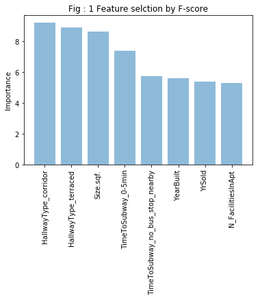

```python
y_pos = np.arange(len(best_features_fscore))
plt.bar(y_pos, feature_importances_fscore, align='center', alpha=0.5)
plt.xticks(y_pos, best_features_fscore, rotation = 90)
plt.ylabel('Importance')
plt.title('Fig : 1 Feature selction by F-score')
plt.show()
```

We will apply this selected features on our wrapper algorithm.

```python
Data[:,fs_indices_fscore].shape
```

```
(5891L, 8L)
```

```python
from sklearn.linear_model import LinearRegression

reg = LinearRegression().fit(D_train[:,fs_indices_fscore], t_train)
LR_Fscore = reg.score(D_test[:,fs_indices_fscore], t_test)
print LR_Fscore

predfs = reg.predict(D_test[:,fs_indices_fscore])
mae_LRfs = metrics.mean_absolute_error(t_test, predfs)

print mae_LRfs
```

```
0.8312712084624383
32358.293657291808
```

From F-score selected features linear regressor algorithm has given 83.13% accuracy score with the test data.

#### Mulual information

Secondly, applying Mulual information method to identify 8 most important features of this dataset.

```python
fs_fit_mutual_info = fs.SelectKBest(fs.mutual_info_classif, k=num_features)
fs_fit_mutual_info.fit_transform(Data, Target)
fs_indices_mutual_info = np.argsort(fs_fit_mutual_info.scores_)[::-1][0:num_features]
print fs_indices_mutual_info

best_features_mutual_info = Data_df.columns[fs_indices_mutual_info].values
print best_features_mutual_info

feature_importances_mutual_info = fs_fit_mutual_info.scores_[fs_indices_mutual_info]
print feature_importances_mutual_info
```

```
[16 24 20 27 18 28  4 14]
['HallwayType_terraced' 'TimeToSubway_no_bus_stop_nearby'
 'TimeToSubway_0-5min' 'SubwayStation_Chil-sung-market'
 'TimeToBusStop_10min~15min' 'SubwayStation_Daegu' 'HeatingType'
 'HallwayType_corridor']
[1.51199275 1.49942074 1.48461035 1.47377057 1.46928246 1.46731024
 1.44228574 1.43471215]
```

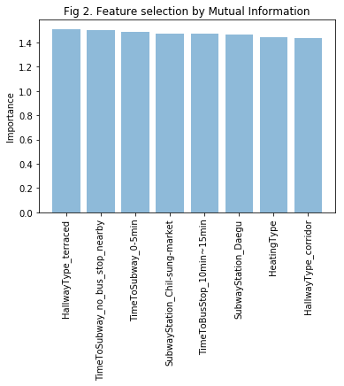

```python
y_pos = np.arange(len(best_features_mutual_info))
plt.bar(y_pos, feature_importances_mutual_info, align='center', alpha=0.5)
plt.xticks(y_pos, best_features_mutual_info, rotation = 90)
plt.ylabel('Importance')
plt.title('Fig 2. Feature selection by Mutual Information')
plt.show()
```

Using these 8 most important features in wrapper algorithm ro find out its accuarcy.

```python
from sklearn.linear_model import LinearRegression

reg = LinearRegression().fit(D_train[:,fs_indices_mutual_info], t_train)
LR_MutualInfo = reg.score(D_test[:,fs_indices_mutual_info], t_test)
print LR_MutualInfo

predmi = reg.predict(D_test[:,fs_indices_mutual_info])
mae_LRmi = metrics.mean_absolute_error(t_test, predmi)

print mae_LRmi
```

[output not shown]

Accuracy score, r-square score, with Mutual information algorithm is very low that is just 48.8%.

#### Random forest

```python
from sklearn.ensemble import RandomForestRegressor

num_features = 8
model_rfi = RandomForestRegressor()
model_rfi.fit(Data, Target)
fs_indices_rfi = np.argsort(model_rfi.feature_importances_)[::-1][0:num_features]
print fs_indices_rfi

best_features_rfi = Data_df.columns[fs_indices_rfi].values
print best_features_rfi

feature_importances_rfi = model_rfi.feature_importances_[fs_indices_rfi]
feature_importances_rfi
```

```
[ 2 16  1  0  6 11  3  8]
['Size.sqf.' 'HallwayType_terraced' 'YrSold' 'YearBuilt'
 'N_Parkinglot.Basement.' 'N_FacilitiesInApt' 'Floor' 'N_elevators']
```

```
array([0.42662867, 0.24325248, 0.16476505, 0.05264628, 0.04503572,
       0.01849986, 0.01559234, 0.00806374])
```

Above are the fearures selected by random forest. We will visualise them using a bar plot in fig 3.

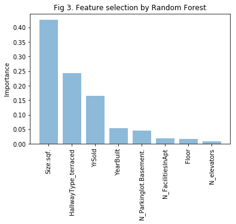

```python
y_pos = np.arange(len(best_features_rfi))
plt.bar(y_pos, feature_importances_rfi, align='center', alpha=0.5)
plt.xticks(y_pos, best_features_rfi, rotation = 90)
plt.ylabel('Importance')
plt.title('Fig 3. Feature selection by Random Forest')
plt.show()
```

Applying these selected 8 best features by random forest in linear regression algorithm.

```python
from sklearn.linear_model import LinearRegression

reg = LinearRegression().fit(D_train[:,fs_indices_rfi], t_train)
LR_RandomForest = reg.score(D_test[:,fs_indices_rfi], t_test)
print LR_RandomForest

predrf = reg.predict(D_test[:,fs_indices_rfi])
mae_LRrf = metrics.mean_absolute_error(t_test, predrf)

print mae_LRrf
```

```
0.8419770454084038
31781.76728950574
```

The regression algorithm give accuracy of 84.19% with the features selected by random forest.

#### Performance Comparison for feature selection:

```python
print('Full Set of Features:', LR_fullset.round(3))
print('F-Score:', LR_Fscore.round(3))
print('Mutual Information:', LR_MutualInfo.round(3))
print('RFI:', LR_RandomForest.round(3))
```

```
('Full Set of Features:', 0.88)
('F-Score:', 0.831)
('Mutual Information:', 0.488)
('RFI:', 0.842)
```

Considering these results, we decide to go with full features for further analysis. Additionally, we don't have too many features as we have already dropped ,many considering correlation analysis in phase I. Thus we will consider all the features to achieve the highest accuracy.

## Hyperparameter Tuning

#### K-Nearest Neighbors (KNN) :

As we have already considered feature selection, we now we stack grid search for KNN hyperparameter tuning via cross-validation.

The KNN hyperparameters are as follows:

number of neighbors (n_neighbors) and the distance metric p.

```python
from sklearn.model_selection import RepeatedKFold, GridSearchCV
from sklearn.preprocessing import StandardScaler
from sklearn.neighbors import KNeighborsRegressor

cv_method = RepeatedKFold(n_splits=5,
                          n_repeats=3,
                          random_state=999)

Data = StandardScaler().fit_transform(Data)

knn_regressor = KNeighborsRegressor()

params_knn_regressor = {'n_neighbors': [1,2,3,4,5],
                        'p': [1, 2, 5]}

gs_knn_regressor = GridSearchCV(estimator=knn_regressor,
                  param_grid=params_knn_regressor,
                  verbose=1,
                  cv=cv_method)

gs_knn_regressor.fit(Data, Target);
```

```
Fitting 15 folds for each of 15 candidates, totalling 225 fits
```

```
[Parallel(n_jobs=1)]: Using backend SequentialBackend with 1 concurrent workers.
[Parallel(n_jobs=1)]: Done 225 out of 225 | elapsed: 15.5min finished
```

```python
print gs_knn_regressor.best_params_
print gs_knn_regressor.best_score_
```

```
{'n_neighbors': 3, 'p': 1}
0.9645583374624912
```

We observe that the optimal KNN model has a R-square score of 0.9645. The best performing KNN selected 3 nearest neighbour with p = 1.

```python
gs_knn_regressor.cv_results_['mean_test_score']
```

```
array([0.95481673, 0.95444658, 0.95386738, 0.96328078, 0.96149052,
       0.96111726, 0.96455834, 0.96248251, 0.96203363, 0.96414112,
       0.96249593, 0.96213302, 0.96365244, 0.96175493, 0.96142574])
```

In order to demonstrate the result following dataset and line plot are presented.

```python
import pandas as pd

results_KNN = pd.DataFrame(gs_knn_regressor.cv_results_['params'])

results_KNN['test_score'] = gs_knn_regressor.cv_results_['mean_test_score']

results_KNN['metric'] = results_KNN['p'].replace([1,2,5], ["Manhattan", "Euclidean", "Minkowski"])
results_KNN
```

|  | n_neighbors | p | test_score | metric |
| --- | --- | --- | --- | --- |
| 0 | 1 | 1 | 0.954817 | Manhattan |
| 1 | 1 | 2 | 0.954447 | Euclidean |
| 2 | 1 | 5 | 0.953867 | Minkowski |
| 3 | 2 | 1 | 0.963281 | Manhattan |
| 4 | 2 | 2 | 0.961491 | Euclidean |
| 5 | 2 | 5 | 0.961117 | Minkowski |
| 6 | 3 | 1 | 0.964558 | Manhattan |
| 7 | 3 | 2 | 0.962483 | Euclidean |
| 8 | 3 | 5 | 0.962034 | Minkowski |
| 9 | 4 | 1 | 0.964141 | Manhattan |
| 10 | 4 | 2 | 0.962496 | Euclidean |
| 11 | 4 | 5 | 0.962133 | Minkowski |
| 12 | 5 | 1 | 0.963652 | Manhattan |
| 13 | 5 | 2 | 0.961755 | Euclidean |
| 14 | 5 | 5 | 0.961426 | Minkowski |

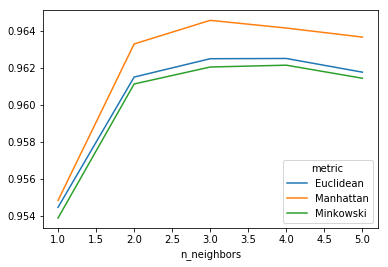

```python
df = results_KNN.pivot(index='n_neighbors', columns='metric',
                       values='test_score')
df.plot()
```

From the plot also, we observe best KNN value at 3 nearest neighbour for Manhattan distance.

```python
from sklearn import metrics

t_pred = gs_knn_regressor.predict(D_test)
mae_KNN = metrics.mean_absolute_error(t_test, t_pred)
r2_KNN = metrics.r2_score(t_test, t_pred)

print mae_KNN
print r2_KNN
```

```
8611.909313725491
0.9850178572522069
```

#### Decision Tree Regressor (DT)

In the following code, we now we stack grid search for DT hyperparameter tuning via cross-validation.

The DT hyperparameters are as follows:

max_depth which is maximum depth of the tree min_samples_split is sample split at each node

```python
from sklearn.tree import DecisionTreeRegressor

from sklearn.model_selection import RepeatedKFold, GridSearchCV
cv_method = RepeatedKFold(n_splits=5, n_repeats=3, random_state=999)

df_regressor = DecisionTreeRegressor()

params_DT = {'max_depth': [3, 4, 5, 6, 7, 8],
             'min_samples_split': [2, 3]}

gs_DT = GridSearchCV(estimator=df_regressor,
                     param_grid=params_DT,
                     cv=cv_method,
                     verbose=1,
                     scoring='neg_mean_squared_error')

gs_DT.fit(Data, Target);
```

```
[Parallel(n_jobs=1)]: Using backend SequentialBackend with 1 concurrent workers.
```

```
Fitting 15 folds for each of 12 candidates, totalling 180 fits
```

```
[Parallel(n_jobs=1)]: Done 180 out of 180 | elapsed:    2.5s finished
```

```python
gs_DT.best_params_
```

```
{'max_depth': 8, 'min_samples_split': 3}
```

For the best accuracy of decision tree, the max_depth is 8 and min_sample_split is 3.

In the following code chunk, we will demostrate the output with the help of table and line graph.

```python
gs_DT.best_score_
```

```
-459725244.9954717
```

```python
results_DT = pd.DataFrame(gs_DT.cv_results_['params'])
results_DT['test_score'] = gs_DT.cv_results_['mean_test_score']
results_DT
```

|  | max_depth | min_samples_split | test_score |
| --- | --- | --- | --- |
| 0 | 3 | 2 | -3.132996e+09 |
| 1 | 3 | 3 | -3.132996e+09 |
| 2 | 4 | 2 | -1.914564e+09 |
| 3 | 4 | 3 | -1.914851e+09 |
| 4 | 5 | 2 | -1.180747e+09 |
| 5 | 5 | 3 | -1.180900e+09 |
| 6 | 6 | 2 | -8.267183e+08 |
| 7 | 6 | 3 | -8.263043e+08 |
| 8 | 7 | 2 | -6.063392e+08 |
| 9 | 7 | 3 | -6.048619e+08 |
| 10 | 8 | 2 | -4.619734e+08 |
| 11 | 8 | 3 | -4.597252e+08 |

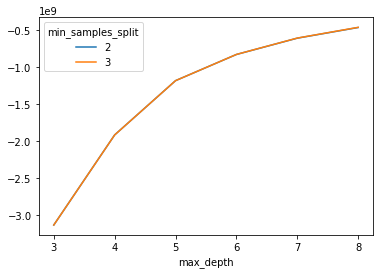

```python
df = results_DT.pivot(index='max_depth', columns='min_samples_split', values='test_score')

df.plot()
```

From the graph above it is clear that hightest accuracy of DT can be observed at maximum depth of 8 and sample split of 3. we haven't considered more depth to the decision tree to avoid over fitting.

```python
t_pred = gs_DT.predict(D_test)
mae_DT = metrics.mean_absolute_error(t_test, t_pred)
r2_DT = metrics.r2_score(t_test, t_pred)

print mae_DT
print r2_DT

print ('Mean Absolute Error (MAE) for LR = ', mae_LR)
print ('R-Squared for LR = ', LR_fullset)
print ('Mean Absolute Error (MAE) for KNN = ', mae_KNN)
print ('R-Squared for KNN = ', r2_KNN)
print ('Mean Absolute Error (MAE) for DT = ', mae_DT)
print ('R-Squared for DT = ', r2_DT)
```

```
12797.390234007822
0.9704638517385219
('Mean Absolute Error (MAE) for LR = ', 27440.362138766308)
('R-Squared for LR = ', 0.8799447465934728)
('Mean Absolute Error (MAE) for KNN = ', 8611.909313725491)
('R-Squared for KNN = ', 0.9850178572522069)
('Mean Absolute Error (MAE) for DT = ', 12797.390234007822)
('R-Squared for DT = ', 0.9704638517385219)
```

After hyperparameter tuning, we have received above output for KNN and DT.

## Performace Analysis:

#### I. Linear regression -

In the following chunk, we are plotting a scatter plot of predicted values by linear model to the actual values.

```
Text(0.5,1,'Fig 4. Scatter plot of performance of Linear regression')
```

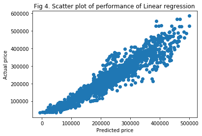

```python
lr = linear_model.LinearRegression()
lr.fit(D_train, t_train)
plt.scatter(lr.predict(D_test), t_test)
plt.xlabel('Predicted price')
plt.ylabel('Actual price')
plt.title('Fig 4. Scatter plot of performance of Linear regression')
```

The graph above demostrates scatter plot of predicted value by linear regression algorithm to its actual price. The scatter plot is fairly linear. Below is the residual plot after applying linear regression model.

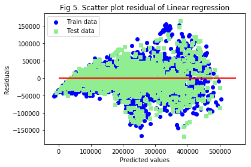

```python
# residual plot
t_train_pred = lr.predict(D_train)
t_test_pred = lr.predict(D_test)

plt.scatter(t_train_pred, t_train_pred - t_train, c='blue', marker='o', label='Train data')
plt.scatter(t_test_pred, t_test_pred - t_test, c='lightgreen', marker='s', label='Test data')
plt.xlabel('Predicted values')
plt.ylabel('Residuals')
plt.legend(loc='upper left')
plt.hlines(y=0 ,xmin=0, xmax=550000, lw=2, color='red')
plt.title('Fig 5. Scatter plot residual of Linear regression')
plt.show()
```

This plot demonstrate that the linear regression algorithm was fairly accurate on predicting prices for lower soldprice than higher sold price. However, there is minor deviation in mid sold price prediction because of large spread of data values.

#### II. k-nearest neighbour regressor

In the following chunk, we are plotting a scatter plot of predicted values by k-nearest neighbour regressor to the actual values.

```
Text(0.5,1,'Fig 6. Scatter plot of performance of KNN')
```

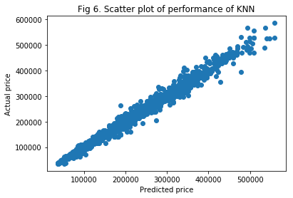

```python
plt.scatter(gs_knn_regressor.predict(D_test), t_test)
plt.xlabel('Predicted price')
plt.ylabel('Actual price')
plt.title('Fig 6. Scatter plot of performance of KNN')
```

The graph above demostrates scatter plot of predicted value by KNN regression algorithm to its actual price. The scatter plot demonstartes excellent accuracy of this regressor. Below is the residual plot after applying KNN regression model.

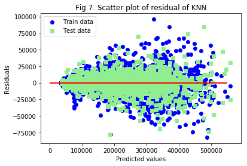

```python
t_train_pred = gs_knn_regressor.predict(D_train)
t_test_pred = gs_knn_regressor.predict(D_test)

plt.scatter(t_train_pred, t_train_pred - t_train, c='blue', marker='o', label='Train data')
plt.scatter(t_test_pred, t_test_pred - t_test, c='lightgreen', marker='s', label='Test data')
plt.xlabel('Predicted values')
plt.ylabel('Residuals')
plt.legend(loc='upper left')
plt.hlines(y=0 ,xmin=0, xmax=550000, lw=2, color='red')
plt.title('Fig 7. Scatter plot of residual of KNN')
plt.show()
```

#### III. Decision Tree Regressor

In the following chunk, we are plotting a scatter plot of predicted values by decision tree regressor to the actual values.

[output not shown]

[figure not shown]

```python
plt.scatter(gs_DT.predict(D_test), t_test)
plt.xlabel('Predicted price')
plt.ylabel('Actual price')
plt.title('Fig 8. Scatter plot of performance of Decision Tree')
```

The graph above demostrates scatter plot of predicted value by Decision tree regression algorithm to its actual price. The scatter plot demonstartes very good accuracy of this regressor. Below is the residual plot after applying DT regression model.

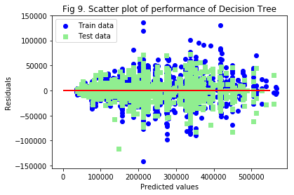

```python
t_train_pred = gs_DT.predict(D_train)
t_test_pred = gs_DT.predict(D_test)

plt.scatter(t_train_pred, t_train_pred - t_train, c='blue', marker='o', label='Train data')
plt.scatter(t_test_pred, t_test_pred - t_test, c='lightgreen', marker='s', label='Test data')
plt.xlabel('Predicted values')
plt.ylabel('Residuals')
plt.legend(loc='upper left')
plt.hlines(y=0 ,xmin=0, xmax=550000, lw=2, color='red')
plt.title('Fig 9. Scatter plot of performance of Decision Tree')
plt.show()
```

From the above residual plot, it is evident that DT regressor was able to predict values fairly correctly for the entire range of sold price. However, there are few evident deviations observed for predicted data from actual values.

## Performance Comparison

- Linear regression Vs K-nearest neighbour
- Decision tree regressor Vs Linear regression
- K-nearest neighbour Vs Decision tree regressor

```python
from sklearn.model_selection import cross_val_score

cv_method_ttest = RepeatedKFold(n_splits=5,
                                n_repeats=3,
                                random_state=999)

cv_results_KNN = cross_val_score(estimator=gs_knn_regressor.best_estimator_,
                                 X=Data,
                                 y=Target,
                                 cv=cv_method_ttest,
                                 n_jobs=-2,
                                 scoring='r2')
cv_results_KNN.mean().round(3)
```

```
0.965
```

```python
cv_results_DT = cross_val_score(estimator=gs_DT.best_estimator_,
                                X=Data,
                                y=Target,
                                cv=cv_method_ttest,
                                n_jobs=-2,
                                scoring='r2')
cv_results_DT.mean().round(3)
```

```
0.959
```

```python
cv_results_LR = cross_val_score(lr,
                                Data,
                                Target,
                                cv=cv_method_ttest,
                                scoring='r2')
cv_results_LR.mean().round(6)
```

```
0.880047
```

```python
from scipy import stats

print(stats.ttest_rel(cv_results_LR , cv_results_KNN))
print(stats.ttest_rel(cv_results_DT, cv_results_LR))
print(stats.ttest_rel(cv_results_KNN, cv_results_DT))

print ('Mean Absolute Error (MAE) for LR  = ', mae_LR)
print ('R-Squared for LR                  = ', LR_fullset)
print ('Mean Absolute Error (MAE) for KNN = ', mae_KNN)
print ('R-Squared for KNN                 = ', r2_KNN)
print ('Mean Absolute Error (MAE) for DT  = ', mae_DT)
print ('R-Squared for DT                  = ', r2_DT)
```

```
Ttest_relResult(statistic=-58.81163709811466, pvalue=3.630989166438017e-18)
Ttest_relResult(statistic=55.036698860531416, pvalue=9.156883508750177e-18)
Ttest_relResult(statistic=6.473095480371086, pvalue=1.4655390835173139e-05)
('Mean Absolute Error (MAE) for LR  = ', 27440.362138766308)
('R-Squared for LR                  = ', 0.8799447465934728)
('Mean Absolute Error (MAE) for KNN = ', 8611.909313725491)
('R-Squared for KNN                 = ', 0.9850178572522069)
('Mean Absolute Error (MAE) for DT  = ', 12797.390234007822)
('R-Squared for DT                  = ', 0.9704638517385219)
```

A p-value smaller than 0.05 indicates a statistically significant difference.

Further KNN has the lowest mean absolute error which is 8611 nad highest accuracy that is r-square value which is 98.5%

Looking at these results, we conclude that at a 95% significance level, KNN is statistically the best model in this competition (considering r-square value) when compared on the test data.

## Limitations and Proposed Solutions

Our modeling strategy has a few flaws and limitation. First, our target variable SoldPrice was continuous in nature and it had big range of data in an uneven distribution. Because of this problem most our algorithm were not able to predict correct values for high price range of apartments as these values were treated as outliers.

Further, For K-nearest neighbor model, the requered computation time was quite high. To avoid this problem either number of observation could be restricted or machine with more computation power should be used.

Lastly, we worked with only a subset of the data. Since data is always valuable, we could re-run our experiments with the entire data while making sure that the train and test split is performed in a proper manner.

## References

- Dr Vural Aksakalli, Machine learning- Course coordinator, RMIT 2019, Class notes and SKLearn Tutorials
- SKLearn Documents, 2019 scikit-learn.org
- Gunhee Park's Dataset, 2017 - www.kaggle.com/gunhee/koreahousedata
- Toward DataScience, WebPortal - towardsdatascience.com